# 30 Day Map Challenge

Wei Jing Ang

2024-10-23

# Set up

```r
# Load libraries
library(tidyverse)
library(sf)
library(ggplot2)
library(patchwork)
library(ghibli)
library(ggrepel)
library(ggtext)
library(glue)
library(tigris)
library(rgeoboundaries)
library(mapview)
```

```r
# Load data
# Mekong river basin
basin <- read_sf("Data/Mekong_basin_delta/Mekong_basin_delta.shp")
countries <- rbind(geoboundaries("china"),
                   geoboundaries("myanmar"),
                   geoboundaries("thailand"),
                   geoboundaries("laos"),
                   geoboundaries("cambodia"),
                   geoboundaries("vietnam"))
india <- geoboundaries("india", adm_lvl = 1) # does not have country level data
india <- india[c(112,118,78,120,110),] # select visible states

# Dams
dams <- read_sf("Data/Dams_1055/Dams_1055.shp")
dams1980 <- read_sf("Data/1980/1980.shp") # 1980
dams1990 <- read_sf("Data/1990/1990_combi.shp") # 1990
dams2000 <- read_sf("Data/2000/2000_combi.shp") # 2000
dams2010 <- read_sf("Data/2010/2010_combi.shp") # 2010
dams2020 <- read_sf("Data/2020/2020_combi.shp") # 2020

# River and lake
river1 <- read_sf("Data/River_1/FLOW1_STRA_3_China.shp") # upper course
river2 <- read_sf("Data/River_2/FLOW1_STRA_5.shp") # middle course
river3 <- read_sf("Data/River_3/FLOW3_CLASS2_TS.shp") # lower course
lake <- read_sf("Data/Lake/HydroLAKES_TS_finer.shp") # Tonle Sap Lake
```

# 1. Points

30DayMapChallenge classic: A map with points. Start the challenge with points. Show individual locations—anything from cities to trees or more abstract concepts. Simple, but a key part of the challenge.

NOTE: TO IMPROVE MAP PROJECTION

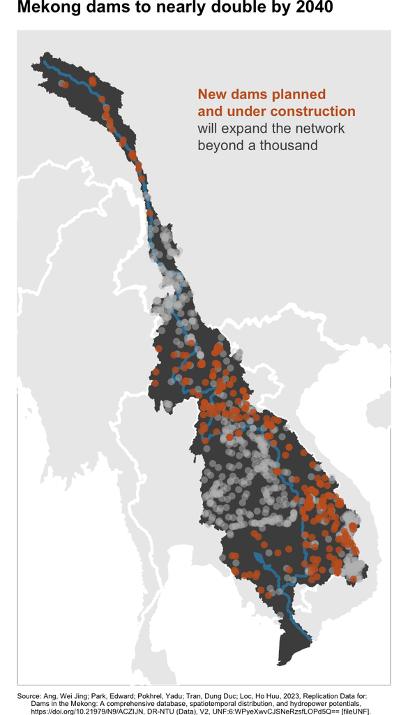

```r
# Define subtitle
annotation1 <- annotation_text <- glue("<span style='color:#C66125;'>**New dams planned<br>and under construction**</span><br>will expand the network<br>beyond a thousand")

ggplot() +

  # Map limits
  xlim(94, 109) +
  ylim(9, 33.5) +

  # Basemap (countries)
  geom_sf(data=countries, fill = "grey92", col = "white", lwd = 0.9)+
  geom_sf(data=st_union(india), fill = "grey92", col = "white", lwd = 0.9)+

  # Mekong basin
  geom_sf(data = basin, fill = "grey30", color = "transparent") + # lower basin
  geom_sf(data = rbind(river1, river2, river3), color = "#3981A4", lwd=0.9) + # river
  geom_sf(data = lake, fill = "#3981A4", color = "transparent") + # Tonle Sap Lake

  # Operating dams
  geom_sf(data = dams %>%
            filter(Status == "Operational"),
          pch = 21, aes(fill = "grey"), color = "transparent", size = 2) +

  # Planned/ constructing dams
  geom_sf(data = dams %>%
            filter(Status == "Under construction" | Status == "Planned"),
          pch = 21, aes(fill = "#C66125"), color = "transparent", size = 2) +

  # Define colours
  scale_fill_manual(values = c(alpha("#C66125",0.8),alpha("grey",0.5)))+

  # Labels
  labs(title = "Mekong dams to nearly double by 2040",
       caption = "Source: Ang, Wei Jing; Park, Edward; Pokhrel, Yadu; Tran, Dung Duc; Loc, Ho Huu, 2023, Replication Data for:
       Dams in the Mekong: A comprehensive database, spatiotemporal distribution, and hydropower potentials,
       https://doi.org/10.21979/N9/ACZIJN, DR-NTU (Data), V2, UNF:6:WPyeXwvCJSNeRzsfLOPd5Q== [fileUNF].")+

  # Annotations
  geom_richtext(aes(x = 101, y = 31,
                    label = annotation1),
                size = 10/.pt,
                colour = "grey30",
                hjust = 0,
                fill = NA,
                label.color = NA)+

  # Define map theme
  theme_void() +
  theme(plot.title = element_text(face="bold",size=12,margin=margin(0,0,10,0)),
        plot.caption = element_text(size=5, hjust = 0),
        panel.background = element_rect(fill="white"),
        panel.border = element_rect(color="white",fill=NA),
        legend.position = "none")
```

```r
ggsave("Output/Day1.png", plot = last_plot(), height = 7, width = 4,units = "in")

# CRS <- c("+proj=eqearth")
# xlim(st_bbox(basin)$xmin-10, st_bbox(basin)$xmax+10) +
# ylim(st_bbox(basin)$ymin-10, st_bbox(basin)$ymax+10) +
```

# 2. Lines

30DayMapChallenge classic: A map with focus on lines. Roads, rivers, routes, or borders—this day is all about mapping connections and divisions. Another traditional way to keep things moving.

# 3. Polygons

30DayMapChallenge classic: A map with polygons. Regions, countries, lakes—this day is for defined shapes that fill space.

# 4. Hexagons

Maps using hexagonal grids. Step away from square grids and try mapping with hexagons. A fun way to show density or spatial patterns.

# 5. A journey

Map any journey. Personal or not. Trace a journey—this could be a daily commute, a long-distance trip, or something from history. The key is to map movement from one place to another.

# 6. Raster

A map using raster data. Rasters are everywhere, but today’s focus is purely on grids and pixels—satellite imagery, heatmaps, or any continuous surface data.

# 7. Vintage style

Map something modern in a vintage aesthetic. Create a map that captures the look and feel of historical cartography but focuses on a contemporary topic. Use muted colors, fonts, and classic elements.

# 8. Data: HDX

Use data from HDX to map humanitarian topics. Explore the datasets from the Humanitarian Data Exchange, covering disaster response, health, population, and development. Map for social good.

# 9. AI only

This day is all about prompt engineering. Use AI tools like DALL-E, MidJourney, Stable Diffusion, or ChatGPT with geospatial capabilities to create a map based on AI-generated content. The challenge is to get the right prompt and critically assess the output—how well does AI capture or distort the map’s intent?

# 10. Pen & paper

Draw a map by hand. Go analog and draw a map using pen and paper. The result doesn’t have to be perfect—it’s about the creative process.

# 11. Arctic

Map the Arctic. Whether it’s ice coverage, wildlife habitats, or the effects of climate change, this day is all about mapping the cold extremes of the Arctic.

# 12. Time and space

Map something where time matters. Visualize change over time—urban growth, migration, or environmental shifts. Show the relationship between time and geography.

# 13. A new tool

Use a tool you’ve never tried before. The challenge has always been about trying new things. Use a tool, software, or drawing technique you’ve never worked with before.

# 14. A world map

Map the whole world. Whether it’s continents, ecosystems, or oceans, this is the day to map the entire planet.

# 15. Data: My data

Map something personal. Map data from your own life—this could be places you’ve traveled, your daily routine, or any other personal touch.

# 16. Choropleth

Classic choropleth map. Use color to show data variation across regions. This simple but effective technique is a staple for showing thematic differences.

# 17. Collaborative map

Collaborate with others on a single map. For today’s challenge, team up! Whether you work with one person or several, the idea is to combine your efforts on a single map.

# 18. 3D

Map with depth. Add a third dimension to your map. Whether it’s visualizing elevation, buildings, or something more abstract, today’s about thinking beyond flat surfaces.

# 19. Typography

Map focused on typography. Let text and words do the heavy lifting today. Whether you’re focusing on place names, labeling, or using text to create shapes and patterns.

# 20. Data: OpenStreetMap

Use OpenStreetMap data to create something. OpenStreetMap offers rich, editable data from roads to buildings and beyond. The goal is to showcase the power of this community-driven dataset.

# 21. Conflict

Map a conflict. Political, territorial, or social—there are conflicts all around us. Map boundaries, tension points, or the outcomes of conflicts.

# 22. 2 colours

Create a map using only 2 colors. No gradients or shading—just two flat colors. This restriction encourages creativity in design and forces you to think about how to clearly convey your message with minimal color.

# 23. Memory

Map based on memory. Create a map of a place you remember—hometown, favorite destination, or somewhere meaningful. It doesn’t need to be perfectly accurate, just how you recall it.

# 24. Only circular shapes

Map using only circles. Everything should be circular. Forget straight lines and sharp edges, and see how creative you can get by sticking to round shapes.

# 25. Heat

Map something related to heat. Focus on heat, whether it’s actual temperature or areas of intensity—like heatmaps of activity or metaphorical heat.

# 26. Map projections

Explore different map projections and how they distort the world. Whether it’s focusing on the classic Mercator, the Peters projection, or a more obscure one like the Waterman Butterfly, today is about playing with how we represent the round Earth on flat surfaces.

# 27. Micromapping

Map something small and precise. Zoom in and map a small area in high detail. It could be a single building, a street corner, or a tiny plot of land. Focus on accuracy at a small scale.

# 28. The blue planet

Map oceans, rivers, and lakes. Focus on water today. Map the oceans, rivers, or lakes, diving deep into marine environments or water systems.

# 29. Data: Overture

Use data from the Overture Maps Foundation. Explore data from Overture Maps Foundation to create a map that highlights new geographic datasets. A great opportunity to dive into open geospatial data!

# 30. The final map

The final challenge—your choice! Revisit a technique from earlier in the month, refine an idea, or try something completely new. End the challenge on a high note with a map that showcases your creativity, growth, or just pure fun!